# Investigation of Medical Appointments in Brazil.

- Introduction
- Data Wrangling
- Exploratory Data Analysis
- Conclusions

## Introduction

This dataset (noshowappointments) consists of recorded information on 110,527 medical appointments at public hospitals in Brazil. The data includes:

- the day and time the appointment was made,
- the day and time for which the appointment was scheduled,
- the neighborhood in which the hospital is located,
- the patient's age,
- the patient's gender,
- whether the patient has received a scholarship (a subsidy for low-income families that meet certain requirements, such as having children going to school),
- whether the patient has hypertension,
- whether the patient has diabetes,
- whether the patient has alcoholism,
- whether the patient has a handicap,
- whether the patient was given an SMS reminder, and
- whether the patient attended the appointment

In this report, I plan to explore the relationship between each given detail and whether or not the patient attended the appointment. I would also like to derive an additional detail - the time between when the appointment was scheduled and the time of the appointment, and see how much this relates with attendance.

I'd also like to see if any of the given health conditions and/or age correlate with a likelihood of making an appointment, as well as if any neighborhoods have a greater or fewer number of patients with the given health conditions

```python
import pandas as pd
import numpy as np
from datetime import datetime
import seaborn as sns
from scipy.stats import mannwhitneyu
import matplotlib.pyplot as plt
import matplotlib.ticker as ticker
%matplotlib inline
```

## Data Wrangling and Cleaning

```python
df = pd.read_csv('noshowappointments-kagglev2-may-2016.csv')
df.head()
```

|  | PatientId | AppointmentID | Gender | ScheduledDay | AppointmentDay | Age | Neighbourhood | Scholarship | Hipertension | Diabetes | Alcoholism | Handcap | SMS_received | No-show |
| --- | --- | --- | --- | --- | --- | --- | --- | --- | --- | --- | --- | --- | --- | --- |
| 0 | 2.987250e+13 | 5642903 | F | 2016-04-29T18:38:08Z | 2016-04-29T00:00:00Z | 62 | JARDIM DA PENHA | 0 | 1 | 0 | 0 | 0 | 0 | No |
| 1 | 5.589978e+14 | 5642503 | M | 2016-04-29T16:08:27Z | 2016-04-29T00:00:00Z | 56 | JARDIM DA PENHA | 0 | 0 | 0 | 0 | 0 | 0 | No |
| 2 | 4.262962e+12 | 5642549 | F | 2016-04-29T16:19:04Z | 2016-04-29T00:00:00Z | 62 | MATA DA PRAIA | 0 | 0 | 0 | 0 | 0 | 0 | No |
| 3 | 8.679512e+11 | 5642828 | F | 2016-04-29T17:29:31Z | 2016-04-29T00:00:00Z | 8 | PONTAL DE CAMBURI | 0 | 0 | 0 | 0 | 0 | 0 | No |
| 4 | 8.841186e+12 | 5642494 | F | 2016-04-29T16:07:23Z | 2016-04-29T00:00:00Z | 56 | JARDIM DA PENHA | 0 | 1 | 1 | 0 | 0 | 0 | No |

PatientId and AppointmentID are simply identifiers so it doesn't seem possible to determine if any are invalid.

Let's start off with null values

```python
df.info()
```

```
<class 'pandas.core.frame.DataFrame'>
RangeIndex: 110527 entries, 0 to 110526
Data columns (total 14 columns):
PatientId         110527 non-null float64
AppointmentID     110527 non-null int64
Gender            110527 non-null object
ScheduledDay      110527 non-null object
AppointmentDay    110527 non-null object
Age               110527 non-null int64
Neighbourhood     110527 non-null object
Scholarship       110527 non-null int64
Hipertension      110527 non-null int64
Diabetes          110527 non-null int64
Alcoholism        110527 non-null int64
Handcap           110527 non-null int64
SMS_received      110527 non-null int64
No-show           110527 non-null object
dtypes: float64(1), int64(8), object(5)
memory usage: 11.8+ MB
```

There are no null values. Next, let's look at age.

```python
df.Age.describe()
```

```
count    110527.000000
mean         37.088874
std          23.110205
min          -1.000000
25%          18.000000
50%          37.000000
75%          55.000000
max         115.000000
Name: Age, dtype: float64
```

It looks like the recorded ages have a minimum value of -1 and a maximum value of 115. Negative ages don't seem valid, though.

```python
df[df.Age <= 0].Age.describe()
```

```
count    3540.000000
mean       -0.000282
std         0.016807
min        -1.000000
25%         0.000000
50%         0.000000
75%         0.000000
max         0.000000
Name: Age, dtype: float64
```

It looks like we have 3540 records of patients with ages less than or equal to 0. Let's drop those

```python
df = df[df.Age > 0]
```

Now let's look at the size of our dataframe. The number of records in it should be 110,527 - 3,540 = 106,987

```python
df.shape[0]
```

```
106987
```

That looks right. Now let's look at the Gender column

```python
df.Gender.value_counts()
```

```
F    70118
M    36869
Name: Gender, dtype: int64
```

That looks acceptable. It shows that the dataset is highly biased towards female patients, though. Let's look at scheduled day and appointment days now.

```python
# Convert each entry to the datatype datetime64, format the entry as YYYY-MM, then display the different values
#  and the number of each in the column.
pd.to_datetime(df.AppointmentDay).apply(lambda x: x.strftime('%Y-%m')).value_counts()
```

```
2016-05    78202
2016-06    25681
2016-04     3104
Name: AppointmentDay, dtype: int64
```

```python
# This line of code does the same as the above cell: it converts each entry to the datetime64 datatype, formats
#  each as YYYY-MM, then displays the different values and the number of each in the column.
pd.to_datetime(df.ScheduledDay).apply(lambda x: x.strftime('%Y-%m')).value_counts()
```

```
2016-05    65362
2016-04    24395
2016-06    13352
2016-03     3488
2016-02      268
2015-12       61
2016-01       60
2015-11        1
Name: ScheduledDay, dtype: int64
```

```python
# This line of code takes the time values in each entry in the format HH:MM, then shows the unique values and count
#  of each in the column.
df.AppointmentDay.apply(lambda x: datetime.strptime(x, '%Y-%m-%dT%H:%M:%SZ').strftime('%H:%M')).value_counts()
```

```
00:00    106987
Name: AppointmentDay, dtype: int64
```

The scheduled days are all in late-2015 to mid-2016 whereas the appointments are all in April through June of 2016. It is curious to note that the data shows that the appointments were all made for a particular date but not a particular time (all on a specific day but a perhaps default time of 00:00.

```python
# The following converts all entries in the dataframe columns to the datetime64 datatype.
df[['ScheduledDay', 'AppointmentDay']] = df[['ScheduledDay', 'AppointmentDay']].applymap(lambda x: datetime.strptime(x, '%Y-%m-%dT%H:%M:%SZ'))
```

```python
# The following shows us the number of ScheduledDay entries that temporally come after the AppointmentDay entry
#  in the same record.
(df.ScheduledDay > df.AppointmentDay).sum()
```

```
37159
```

```python
# The following takes the records with the later ScheduledDay values (as found in the previous cell) and subsets
#  those rows of the dataframe. Then, we see the number of each 'No-show' value in the dataframe.
df[df.ScheduledDay > df.AppointmentDay]['No-show'].value_counts()
```

```
No     35413
Yes     1746
Name: No-show, dtype: int64
```

## Exploratory Data Analysis

### Representativeness of data

We already saw previously that the sampled population seems quite skewed - females represent nearly twice the proportion of the population as do males. Let us reiterate this numerically and in a graphical visualization.

Afterwards, we will examine whether the following other aspects seem plausible:

- Age
- Scholarship
- Hypertension
- Diabetes
- Alcoholism
- Handcap

```python
gender = df.Gender.value_counts()
print('Of the data, {:.1f}% of the population is female\n  whereas {:.1f} of the population is male'.format(100*gender[0]/sum(gender), 100*gender[1]/sum(gender)))
```

```
Of the data, 65.5% of the population is female
  whereas 34.5 of the population is male
```

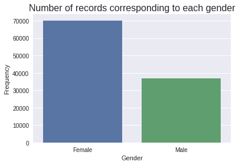

```python
# The following creates a visualization of the number of records of patients of each gender in the dataframe

ax = sns.countplot(df.Gender)
plt.ylabel('Frequency')
plt.title('Number of records corresponding to each gender', fontsize=16)
ax.set(xticklabels=['Female','Male'])
plt.show()
```

Since multiple records can correspond to a single patient, let's look at the number of individuals of each gender represented.

```python
# In taking the number of unique PatientId values corresponding to each gender, we can look at the number of individuals
#  of each gender, rather than the number of records corresponding to each gender (multiple records can correspond
#  to the same individual).
df.groupby('Gender').PatientId.nunique()
```

```
Gender
F    39081
M    21189
Name: PatientId, dtype: int64
```

It looks like there are still almost twice as many females as there are males. This should be kept in mind.

Now, let's move on to age and only examine the unique ages in the sample..

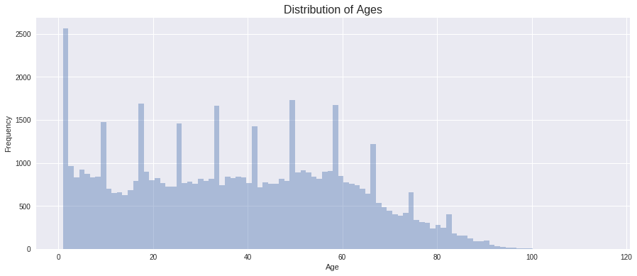

```python
# The following creates a histogram of the ages in the records of the dataframe.

# First, we create a larger figure.
plt.figure(figsize=(15,6))

# Next, we create a histogram. We input the relevant columns, use drop_duplicates() to make sure we only count
#  each unique patient once, set kde=False because we won't use a kde curve, and increase the number of bins appropriately.
sns.distplot(df[['PatientId','Age']].drop_duplicates('PatientId').Age, kde=False, bins=100)

# Next, we set the y-label and title of the plot.
plt.ylabel('Frequency')
plt.title('Distribution of Ages', fontsize=16)

# The visualization is shown using plt.show() so as to avoid outputting distracting text.
plt.show()
```

It looks like the ages in our sample are quite skewed. To be fair, it seems possible that ages in the population are positively skewed in a similar manner. It seems particular age ranges are disproportionately common (e.g., the spikes in the plot), which may not occur in the population at large. This should be kept in mind as a potential shortcoming of the dataset.

Let's look at how age relates to gender.

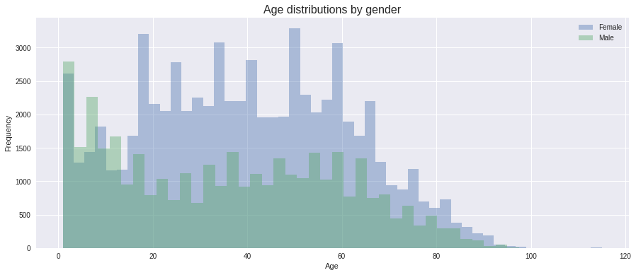

```python
# The following creates a histogram of the ages in the records of the dataframe corresponding to males and a histogram
#  of ages in the records corresponding to females. We can superimpose without changing alpha levels because
#  histograms in seaborn default to an alpha level below one.

# First, we create a larger figure.
plt.figure(figsize=(15,6))

# We create dataframes by subsetting the relevant records of df.
males = df[df['Gender']=='M']
females = df[df['Gender']=='F']

# Next, we create histograms, inputting the relevant data. Again, we don't need kde curves. We can superimpose
#  the plots on the same axis because the histograms each have a suitably low alpha level.
sns.distplot(females['Age'], kde=False, label='Female')
sns.distplot(males['Age'], kde=False, label='Male')

# Set appropriate labels
plt.ylabel("Frequency")
plt.title("Age distributions by gender", fontsize=16)
plt.legend()

# The visualization is shown using plt.show() so as to avoid outputting distracting text.
plt.show()
```

Unfortunately, neither distribution looks to be normally distributed. For that reason, we will proceed using the Mann-Whitney test.

```python
# We use the mannwhitneyu() function in the scipy.stats library to see how probable it is to obtain both samples
#  (ages of males and ages of females) from the same population. We will just display the p-value.
_, p = mannwhitneyu(males['Age'], females['Age'])
p
```

```
2.1131513885155468e-209
```

Now, let's move on to having a scholarship. Again, since we are considering the sampled individuals, let us only consider unique patients

```python
def bar(xdata, ydata, title_text):
    """
    This function creates a barchart with xdata on the x-axis and y-data on the y-axis. The visualization is shown
      using plt.show() so as to avoid outputting distracting text.

    Inputs:
      xdata : a 1D group of numbers of the same size as ydata
      ydata : a 1D group of numbers of the same size as xdata
    Output:
      None
    """

    # First, we use the barplot() function in the Seaborn library with the given arguments and store the result as ax.
    ax = sns.barplot(x=xdata, y=ydata)

    # Set the title as per the given argument and y-axis label appropriately.
    plt.title(title_text, fontsize=16)
    plt.ylabel('Frequency')

    # Set the x-axis tick labels to informative values
    ax.set(xticklabels=['No','Yes'])

    return ax
```

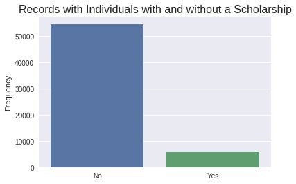

```python
# The following uses the bar() function we defined earlier to see the relative amounts of records of people with and
#  without a scholarship.

df_to_plot = df[['PatientId','Scholarship']].drop_duplicates('PatientId').Scholarship.value_counts()
ax = bar(df_to_plot.index, df_to_plot, 'Records with Individuals with and without a Scholarship')

# The visualization is shown using plt.show() so as to avoid outputting distracting text.
plt.show()
```

It looks like the vast majority of the sampled individuals don't have a scholarship. This may or may not be representative of the Brazilian population. Without more information, we cannot say which is the case.

Now, let's move on to the given pathologies (Hypertension, Diabetes, and Alcoholism).

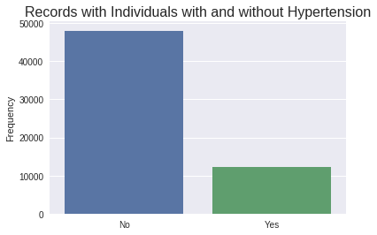

```python
# The following uses the bar() function we defined earlier to see the relative amounts of records of people with and
#  without hypertension.

df_to_plot = df[['PatientId','Hipertension']].drop_duplicates('PatientId').Hipertension.value_counts()
ax = bar(df_to_plot.index, df_to_plot, 'Records with Individuals with and without Hypertension')

# The visualization is shown using plt.show() so as to avoid outputting distracting text.
plt.show()
```

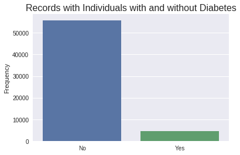

```python
# The following uses the bar() function we defined earlier to see the relative amounts of records of people with and
#  without diabetes.

df_to_plot = df[['PatientId','Diabetes']].drop_duplicates('PatientId').Diabetes.value_counts()
ax = bar(df_to_plot.index, df_to_plot, 'Records with Individuals with and without Diabetes')

# The visualization is shown using plt.show() so as to avoid outputting distracting text.
plt.show()
```

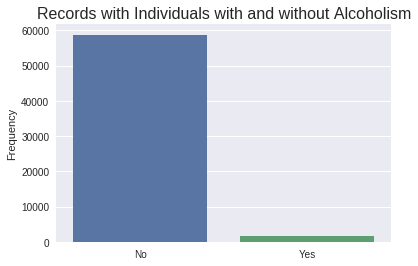

```python
# The following uses the bar() function we defined earlier to see the relative amounts of records of people with and
#  without alcoholism.

df_to_plot = df[['PatientId','Alcoholism']].drop_duplicates('PatientId').Alcoholism.value_counts()
ax = bar(df_to_plot.index, df_to_plot, 'Records with Individuals with and without Alcoholism')

# The visualization is shown using plt.show() so as to avoid outputting distracting text.
plt.show()
```

It looks like the population contains far more people without hypertension, diabetes, or alcoholism, than people with these pathologies. This intuitively seems possibly representative of the Brazilian population, but such cannot be known for sure without additional data.

Now, let's move on to having a handicap.

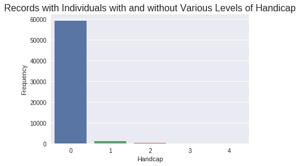

```python
# The following creates a visualization to see the relative amounts of records of people with and without various
#  levels of handicap.

df_to_plot = df[['PatientId','Handcap']].drop_duplicates('PatientId').Handcap.value_counts()
ax = sns.barplot(x=df_to_plot.index, y=df_to_plot)
plt.ylabel('Frequency')
plt.xlabel('Handcap')
plt.title('Records with Individuals with and without Various Levels of Handicap', fontsize=16)

# The visualization is shown using plt.show() so as to avoid outputting distracting text.
plt.show()
```

Again, there are far more people without a handicap than people with a handicap. This also seems possibly representative of the Brazilian population, but such cannot be known for sure without additional data.

Let's also look at the number of times an SMS reminder is sent and the number of no-shows in order that we may better understand policies and the nature of the dataset.

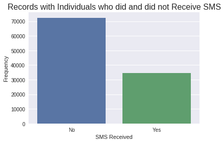

```python
# The following creates a visualization to see the relative numbers of people who did and did not receive SMS.

ax = sns.countplot(df['SMS_received'])
plt.xlabel('SMS Received')
plt.ylabel('Frequency')
plt.title('Records with Individuals who did and did not Receive SMS', fontsize=16)
ax.set(xticklabels=['No','Yes'])

# The visualization is shown using plt.show() so as to avoid outputting distracting text.
plt.show()
```

```python
attendance = df['No-show'].value_counts()
print('Of the data, {:.1f}% of the appointments were attended\n whereas {:.1f}% of the appointments were not attended'.format(100*attendance[0]/sum(attendance), 100*attendance[1]/sum(attendance)))
```

```
Of the data, 79.7% of the appointments were attended
 whereas 20.3% of the appointments were not attended
```

It looks like more often than not, SMS reminders are not received and far more people show up for their appointments than do not. The former seems like an unwise but plausible policy whereas the latter seems sensible, though its representativeness is questionable.

### Relationships

Now, let us look to see:

- If there exist relationships between the given variables and attendance,
- If there exists a relationship between the time between the scheduling of an appointment and the scheduled time and attendance,

We'll start with relationships between some of the given variables (gender, scheduled day, appointment day, age, neighborhood of the hospital, scholarship, hypertension, diabetes, alcoholism, being handicapped, and SMS reminders) and attendance

Before we begin, it may be helpful to perform a cursory overview of the Pearson correlations between variables and attendance

```python
# Create a copy of df so we don't modify it in the following. Convert the 'No-show' column values in the copy
#  to numeric values so a correlational value can be found with respect to it.
corr_df = df.copy()
corr_df['No-show'] = corr_df['No-show'].apply(lambda x: 0 if x=='No' else 1)

# Use the corr() function in the Pandas library with two of the methods built into the function
methods = ['pearson', 'spearman']
for method in methods:
    print('\n{}:'.format(method.title()))
    print(corr_df.corr(method=method)['No-show'])
```

```
Pearson:
PatientId       -0.001083
AppointmentID   -0.161578
Age             -0.067025
Scholarship      0.029370
Hipertension    -0.037280
Diabetes        -0.015928
Alcoholism      -0.000517
Handcap         -0.006389
SMS_received     0.127253
No-show          1.000000
Name: No-show, dtype: float64

Spearman:
PatientId       -0.000579
AppointmentID   -0.170938
Age             -0.068417
Scholarship      0.029370
Hipertension    -0.037280
Diabetes        -0.015928
Alcoholism      -0.000517
Handcap         -0.007603
SMS_received     0.127253
No-show          1.000000
Name: No-show, dtype: float64
```

Of note, however, is the fact that Pearson correlation is meaningful only for linear relationships between, while Spearman correlation attempts to address nonlinearity but is meaningful for only monotonic relationships. Thus, the obtained values should be taken with caution and we will attempt visual inspection of relationships.

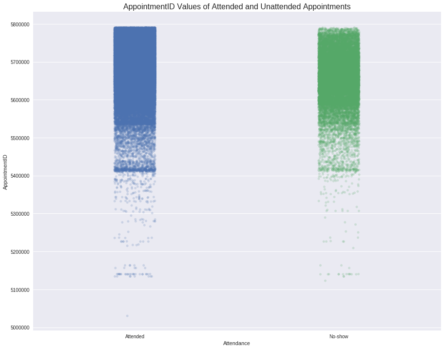

```python
# Create a larger figure
plt.figure(figsize=(15,12))

# Plot the values and set appropriate labels. Use jittering and a lower alpha because there are so many points (AppointmentID values)
ax = sns.stripplot(x='No-show', y='AppointmentID', data=df, jitter=True, alpha=.2)
plt.ylabel('AppointmentID')
plt.xlabel('Attendance')
plt.title('AppointmentID Values of Attended and Unattended Appointments', fontsize=16)
ax.set_xticklabels(['Attended','No-show'])

# The visualization is shown using plt.show() so as to avoid outputting distracting text.
plt.show()
```

Let us move on now to the relationship between gender and attendance

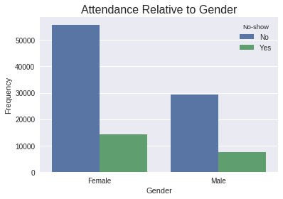

```python
# The following creates a visualization showing how gender relates to attendance. We will use the hue parameter
#  of the countplot() function in the Seaborn library to separate according to attendance

ax = sns.countplot(x=df['Gender'], hue=df['No-show'])
plt.ylabel('Frequency')
ax.set(xticklabels=['Female','Male'])
plt.title("Attendance Relative to Gender", fontsize=16)

# The visualization is shown using plt.show() so as to avoid outputting distracting text.
plt.show()
```

```python
# In the following, we use the value_counts() method to see how many appointments with individuals of each gender
#  were and were not attended.

f_attendance = df[df['Gender']=='F']['No-show'].value_counts()
m_attendance = df[df['Gender']=='M']['No-show'].value_counts()
attendance = df['No-show'].value_counts()
print('In the data, {:.1f}% of the appointments for females were attended\n  whereas {:.1f}% of the appointments for females were not attended\n'.format(100*f_attendance[0]/sum(f_attendance), 100*f_attendance[1]/sum(f_attendance)))
print('In the data, {:.1f}% of the appointments for males were attended\n  whereas {:.1f}% of the appointments for males were not attended'.format(100*m_attendance[0]/sum(m_attendance), 100*m_attendance[1]/sum(m_attendance)))
```

```
In the data, 79.6% of the appointments for females were attended
  whereas 20.4% of the appointments for females were not attended

In the data, 79.9% of the appointments for males were attended
  whereas 20.1% of the appointments for males were not attended
```

Now, let us look to see if there is a relationship between scheduled day and attendance.

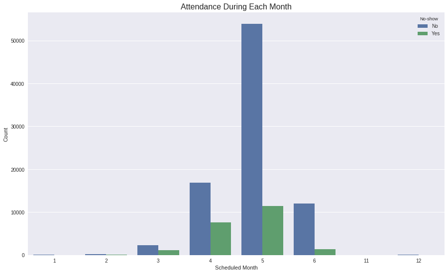

```python
# In the following we create a visualization to see the number of attended and unattended appointments scheduled
#  in each month.

# Create a larger figure
plt.figure(figsize=(15,9))

# Create a column containing the month attribute of the datetime object in the ScheduledDay column of the same record
df['ScheduledMonth'] = df['ScheduledDay'].apply(lambda x: x.date().month)

# Create a visualization using the countplot() method in the Seaborn library. Again, we use the hue parameter to
#  discriminate appointments that were and were not attended.
sns.countplot(x=df['ScheduledMonth'], hue=df['No-show'])

# Set appropriate labels.
plt.xlabel('Scheduled Month')
plt.ylabel('Count')
plt.title('Attendance During Each Month', fontsize=16)

# The visualization is shown using plt.show() so as to avoid outputting distracting text.
plt.show()
```

It seems the sample doesn't include many appointments made in months 1, 2, 3, 11, and 12. It includes no appointments made in months 7, 8, 9, and 10. It thus seems advisable to only consider appointments made in months 4, 5, and 6. However, it doesn't seem fair to extrapolate those months to the entire year so it doesn't seem that we can conclude that there is a relationship between the month in which the appointment was scheduled and attendance.

[figure not shown]

```python
# Create a larger figure
plt.figure(figsize=(15,9))

# Create a column containing the day attribute of the datetime object (in the AppointmentDay column of the same
#  record) with its date() function applied to it.
df['ApptDay'] = df['AppointmentDay'].apply(lambda x: x.date().day)

# Get the percentage of attended and unattended appointments corresponding to each appointment day.
data_to_plot = df[['PatientId','No-show','ApptDay']].groupby(['ApptDay','No-show'], as_index=False).count()
select_sums = data_to_plot[['ApptDay','PatientId']].groupby('ApptDay', as_index=False).count()
select_sums = list(select_sums['PatientId'].values)
data_to_plot = data_to_plot[data_to_plot['No-show']=='No']
data_to_plot['PatientId'] = data_to_plot['PatientId'] / select_sums

# Plot the values and set appropriate labels
ax = sns.barplot(x='ApptDay', y='PatientId', data=data_to_plot)
plt.ylabel('Percentage of Appointments Attended')
plt.xlabel('Appointment Day of Month')
plt.title('Percentage Attendance on each Appointment Day of the Month', fontsize=16)

# The visualization is shown using plt.show() so as to avoid outputting distracting text.
plt.show()
```

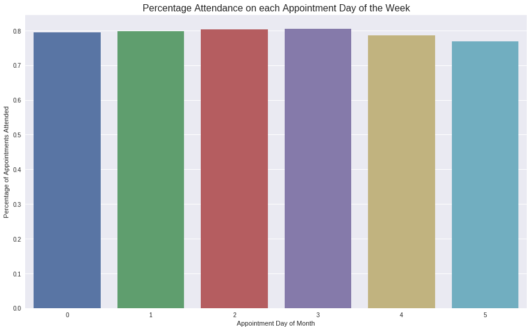

```python
# Create a larger figure
plt.figure(figsize=(15,9))

# Create a column containing the result of the weekday method of the datetime object (in the AppointmentDay column of
#  the same record) with its date() function applied to it. 0 = Monday, ..., 5 = Saturday.
df['ApptDay'] = df['AppointmentDay'].apply(lambda x: x.date().weekday())

# Get the percentage of attended and unattended appointments corresponding to each appointment day.
data_to_plot = df[['PatientId','No-show','ApptDay']].groupby(['ApptDay','No-show'], as_index=False).count()
select_sums = data_to_plot[['ApptDay','PatientId']].groupby('ApptDay', as_index=False).sum()
select_sums = list(select_sums['PatientId'].values)
data_to_plot = data_to_plot[data_to_plot['No-show']=='No']
data_to_plot['PatientId'] = data_to_plot['PatientId'] / select_sums

# Plot the values and set appropriate labels.
ax = sns.barplot(x='ApptDay', y='PatientId', data=data_to_plot)
plt.ylabel('Percentage of Appointments Attended')
plt.xlabel('Appointment Day of Month')
plt.title('Percentage Attendance on each Appointment Day of the Week', fontsize=16)

# The visualization is shown using plt.show() so as to avoid outputting distracting text.
plt.show()
```

```python
# The following shows the numerical values
print('Table of Attendance Ratios on Appointment Days')
data_to_plot.columns = ['Appointment Day', 'No-show', 'Attendance.Ratio']
data_to_plot
```

```
Table of Attendance Ratios on Appointment Days
```

|  | Appointment Day | No-show | Attendance.Ratio |
| --- | --- | --- | --- |
| 0 | 0 | No | 0.793864 |
| 2 | 1 | No | 0.797672 |
| 4 | 2 | No | 0.802790 |
| 6 | 3 | No | 0.805270 |
| 8 | 4 | No | 0.786623 |
| 10 | 5 | No | 0.769231 |

```python
# The following shows the overall attendance ratios
df['No-show'].value_counts() / df['No-show'].count()
```

```
No     0.797359
Yes    0.202641
Name: No-show, dtype: float64
```

```python
print("If we assume appointment days are in the variable AppointmentDay:")
print('  Number of Saturday appointments: {}'.format(df[(df['No-show']=='No') & (df['ApptDay']==5)].shape[0]))
print('  Proportion of Saturday appointments: {}'.format(df[(df['No-show']=='No') & (df['ApptDay']==5)].shape[0] / df.shape[0]))

df['ApptDay'] = df['ScheduledDay'].apply(lambda x: x.date().weekday())
data_to_plot = df[['PatientId','No-show','ApptDay']].groupby(['ApptDay','No-show'], as_index=False).count()
select_sums = data_to_plot[['ApptDay','PatientId']].groupby('ApptDay', as_index=False).sum()
select_sums = list(select_sums['PatientId'].values)
data_to_plot = data_to_plot[data_to_plot['No-show']=='No']
data_to_plot['PatientId'] = data_to_plot['PatientId'] / select_sums

print("\nIf we assume appointment days are in the variable ScheduledDay:")
print('  Number of Saturday appointments: {}'.format(df[(df['No-show']=='No') & (df['ApptDay']==5)].shape[0]))
print('  Proportion of Saturday appointments: {}'.format(df[(df['No-show']=='No') & (df['ApptDay']==5)].shape[0] / df.shape[0]))
```

```
If we assume appointment days are in the variable AppointmentDay:
  Number of Saturday appointments: 30
  Proportion of Saturday appointments: 0.0002804079000252367

If we assume appointment days are in the variable ScheduledDay:
  Number of Saturday appointments: 21
  Proportion of Saturday appointments: 0.0001962855300176657
```

Apparently, appointment day doesn't correlate well with attendance. Perhaps fewer Saturday appointments are attended than all appointments (a difference of approximately 2.8%), but the existence of a relationship cannot be determined because there are so few samples pertaining to Saturday appointments (0.02% of the dataset if we assume that appointment days are in the variable AppointmentDay; 0.0196% of the dataset if we assume that appointment days are in the variable ScheduledDay).

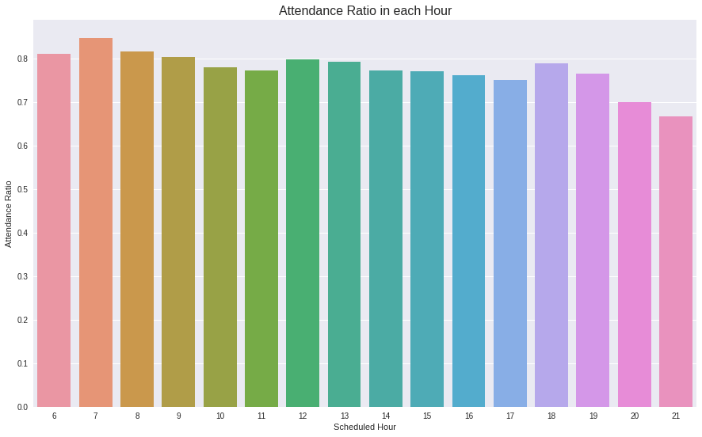

```python
# Create a larger figure
plt.figure(figsize=(15,9))

# Create a column containing the hour attribute of the datetime object (in the ScheduledDay column of
#  the same record) with its time() function applied to it.
df['ScheduledHour'] = df['ScheduledDay'].apply(lambda x: x.time().hour)

# Get the percentage of attended and unattended appointments corresponding to each hour.
data_to_plot = df[['ScheduledHour','No-show','PatientId']].groupby(['ScheduledHour','No-show'], as_index=False).count()
ydata_num = pd.DataFrame(data=(data_to_plot[data_to_plot['No-show']=='No']['PatientId'].values), index=[i for i in set(data_to_plot['ScheduledHour'].values)])
ydata_denom = pd.DataFrame(data=(data_to_plot[['ScheduledHour','PatientId']].groupby('ScheduledHour').sum().values), index=[i for i in set(data_to_plot['ScheduledHour'].values)])
data_to_plot = ydata_num / ydata_denom

# Plot the values and set appropriate labels.
ax = sns.barplot(x=data_to_plot.index, y=data_to_plot[0])
plt.xlabel("Scheduled Hour")
plt.ylabel("Attendance Ratio")
plt.title("Attendance Ratio in each Hour", fontsize=16)

# The visualization is shown using plt.show() so as to avoid outputting distracting text.
plt.show()
```

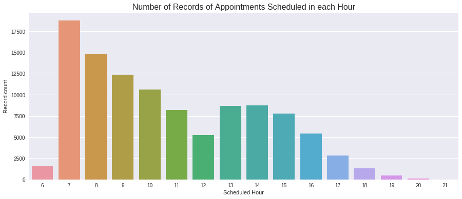

```python
# Create a larger figure
plt.figure(figsize=(15,6))

# We want to look at the number of records per scheduled hour. For this, we could either use the value_counts()
#  method or a groupby().sum(). We want this plot to match the plot above so we'll sort the dataframe by values
#  in the Hour column
scheduledHourData = df.ScheduledHour.value_counts()
data_to_plot = pd.DataFrame({'Hour' : scheduledHourData.index.values,
              'Count': scheduledHourData}).sort_values(by='Hour')

# Plot the values and set appropriate labels
sns.barplot(x=data_to_plot['Hour'], y=data_to_plot['Count'])
plt.xlabel("Scheduled Hour")
plt.ylabel("Record count")
plt.title("Number of Records of Appointments Scheduled in each Hour", fontsize=16)

# The visualization is shown using plt.show() so as to avoid outputting distracting text.
plt.show()
```

Now let us see if there is a relationship between age and attendance.

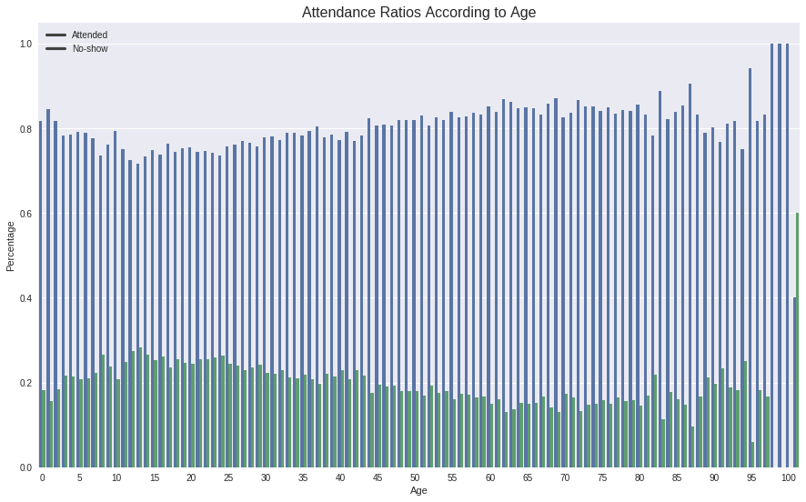

```python
# Create a larger figure
plt.figure(figsize=(15,9))

# Get the count of attendance by each age. Group the values by attendance and divide by the total to get ratios.
df[['Age','No-show','PatientId']].groupby(['Age','No-show'], as_index=False).count()
attendance_by_age = df[['Age','No-show','PatientId']].groupby(['Age','No-show']).count()
data_to_plot = attendance_by_age / attendance_by_age.groupby('Age').sum()
data_to_plot.reset_index(level=['Age','No-show'], inplace=True)

# Plot the values and set appropriate labels
ax = sns.barplot(data=data_to_plot, x='Age', y='PatientId', hue='No-show')
plt.ylabel('Percentage')
plt.title("Attendance Ratios According to Age", fontsize=16)
plt.legend(['Attended','No-show'], loc=2)

# The x ticks would by default by quite dense so as to be unreadable. Thus, we'll set the ticks to display at multiples of 5
ax.xaxis.set_major_locator(ticker.MultipleLocator(5))
ax.xaxis.set_major_formatter(ticker.ScalarFormatter())

# The visualization is shown using plt.show() so as to avoid outputting distracting text.
plt.show()
```

```python
# We'll need to subset relevant cells of the dataframe (the values in the 'Age' columns of record of which
#  'No-show' values are 'Yes' or 'No'). Again, we don't want the test statistic - we only want to display the p-value

_, p = mannwhitneyu(df[df['No-show']=='Yes']['Age'], df[df['No-show']=='No']['Age'])
p
```

```
3.203713415890118e-111
```

It looks like the ratio of attendance is higher at birth, then drops a bit, then rises with age, somewhat like a horizontally truncated parabola, though the correlation seems weak. A further Mann-Whitney U test does not disagree with our suspicion. The test results argue that it is highly likely (i.e., we can say this with more than 99% confidence) that the ages of patients at appointments that were attended and the ages of patients at appointments that were not attended were drawn from independent distributions.

Now, let us see if neighborhood relates to attendance rate.

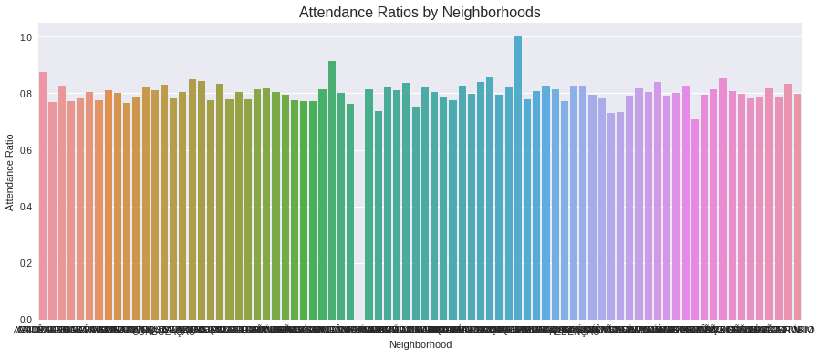

```python
# Create a larger figure
plt.figure(figsize=(15,6))

# We want to see frequencies of neighborhood versus attendance so we'll use the crosstab() function in the pandas
#  library, setting the index parameter to the 'Neighbourhood' column and the columns parameter to the 'No-show'
#  column, and the margins parameter to True, as we'd like to see the total.
ct = pd.crosstab(index=df['Neighbourhood'], columns=df['No-show'], margins=True)

# We divide the values in the 'No' column by the values in the 'All' column
ct['No'] = ct['No'] / ct['All']
ct['count'] = df[['Neighbourhood','AppointmentID']].groupby('Neighbourhood').count()['AppointmentID']

# We could sort by attendance ratio if we want to force a correlation.
#ct.sort_values(by='No', inplace=True)

# Plot the values and set appropriate labels
ax = sns.barplot(x=ct.index, y=ct['No'])
plt.ylabel("Attendance Ratio")
plt.xlabel('Neighborhood')
plt.title('Attendance Ratios by Neighborhoods', fontsize=16)

# The visualization is shown using plt.show() so as to avoid outputting distracting text.
plt.show()
```

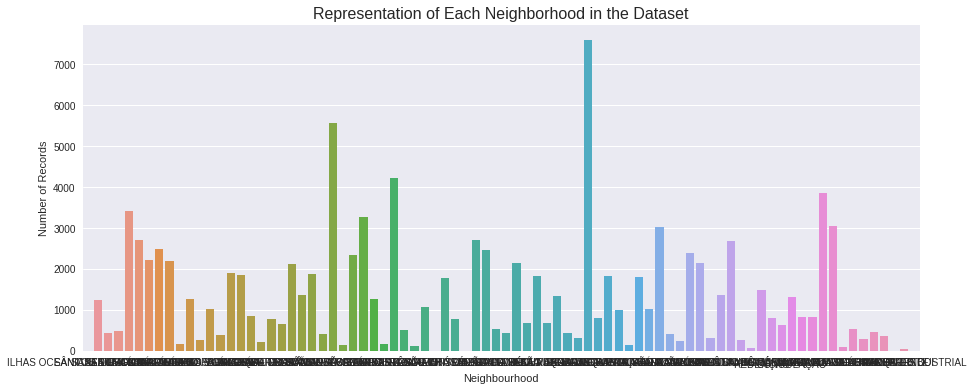

```python
# Create a larger figure
plt.figure(figsize=(15,6))

# We could sort ct according to attendance ratio as calculated above
ct.sort_values(by='No', inplace=True)

# Plot the values and set appropriate labels
ax = sns.barplot(x=ct.index, y=ct['count'])
plt.ylabel("Number of Records")
plt.title("Representation of Each Neighborhood in the Dataset", fontsize=16)

# The visualization is shown using plt.show() so as to avoid outputting distracting text.
plt.show()
```

Tick labels on the x-axis a particularly dense so as to be difficult to read, but this doesn't matter for drawing our current conclusions. There seems to exist a relationship between hospital neighborhood and attendance ratio if we sort the neighborhoods by attendance ratio. Unfortunately, the neighborhoods attendance ratios that stand out are very poorly represented. Thus, it seems we can't infer a relationship between neighborhood and attendance without further information.

Now, let us look to see if there exists a relationship between scholarship and appointment attendance. Since there is such a great difference between the number of individuals with and without scholarship, we will have to consider relative frequencies.

```python
def freq_table(col, ind):
    """
    This function creates a relative frequency table by use of the crosstab() function in pandas. The relevant
      categories are the column names of df indicated by the argument col and the 'No-show' column.
      Ind gives the names of the indices of the table.
    Inputs:
      col : the name of a column of df
      ind : a list of strings to which the index should be assigned
    Output:
      relevant cells of the table, not including the cells corresponding to totals.
    """
    freq_table = pd.crosstab(index=df[col], columns=df['No-show'], margins=True)

    # Set column names appropriately
    freq_table.columns = ['Attended', 'Did Not Attend', 'Total']

    # Remove the row corresponding to column totals because we won't need it
    freq_table = freq_table.iloc[:-1]

    # Set the index to ind
    freq_table.index = ind

    # Divide by the values with corresponding indices in the 'Total' column and multiply the quotient by 100 to obtain
    #  relative frequencies
    freq_table = 100 * freq_table.div(freq_table['Total'], axis=0)

    return freq_table[['Attended', 'Did Not Attend']]
```

```python
print('Table of Scholarship vs Attendance')
freq_table('Scholarship',['No Scholarship','Scholarship'])
```

```
Table of Scholarship vs Attendance
```

|  | Attended | Did Not Attend |
| --- | --- | --- |
| No Scholarship | 80.131631 | 19.868369 |
| Scholarship | 76.214266 | 23.785734 |

It looks like there is a very slight relationship between having a scholarship and attending an appointment. More appointments with individuals without scholarships were attended, but not much more. A relationship may exist but if so, it is not strong or definite.

Now, let us consider the given pathologies (hypertension, diabetes, and alcoholism). As before, we will have to consider relative frequencies

```python
print('Table of Hypertension vs Attendance')
freq_table('Hipertension', ['No Hypertension', 'Hypertension'])
```

```
Table of Hypertension vs Attendance
```

|  | Attended | Did Not Attend |
| --- | --- | --- |
| No Hypertension | 78.977766 | 21.022234 |
| Hypertension | 82.698041 | 17.301959 |

```python
print('Table of Diabetes vs Attendance')
freq_table('Diabetes', ['No Diabetes', 'Diabetes'])
```

```
Table of Diabetes vs Attendance
```

|  | Attended | Did Not Attend |
| --- | --- | --- |
| No Diabetes | 79.554541 | 20.445459 |
| Diabetes | 81.996727 | 18.003273 |

```python
print('Table of Alcoholism vs Attendance')
freq_table('Alcoholism', ['No Alcoholism', 'Alcoholism'])
```

```
Table of Alcoholism vs Attendance
```

|  | Attended | Did Not Attend |
| --- | --- | --- |
| No Alcoholism | 79.732116 | 20.267884 |
| Alcoholism | 79.851190 | 20.148810 |

It looks like individuals with pathologies were very slightly more likely to attend their appointments, with the greatest difference seen in individuals with hypertension and the least difference seen in individuals with alcoholism. The attendance ratio differences are slight, though we can perhaps at least consider a relationship between appointment attendance and being hypertensive. There may perhaps also exist a slight relationship between attendance and having diabetes. Without further information, the existence of a relationship between alcoholism and attendance is uncertain.

Now, let us see if there is a relationship between being handicapped and appointment attendance. Also as before, there is a substantial disparity between the number of individuals in each category and so we will have to consider relative frequencies.

```python
print('Table of Handicap vs Attendance')
freq_table('Handcap', ['No Handicap', 'Handicap Level 1', 'Handicap Level 2', 'Handicap Level 3', 'Handicap Level 4'])
```

```
Table of Handicap vs Attendance
```

|  | Attended | Did Not Attend |
| --- | --- | --- |
| No Handicap | 79.691065 | 20.308935 |
| Handicap Level 1 | 82.067614 | 17.932386 |
| Handicap Level 2 | 79.781421 | 20.218579 |
| Handicap Level 3 | 76.923077 | 23.076923 |
| Handicap Level 4 | 66.666667 | 33.333333 |

```python
# To see the number of people with each level of handicap, we could use groupby().count() or the value_counts() method
df['Handcap'].value_counts()
```

```
0    104747
1      2041
2       183
3        13
4         3
Name: Handcap, dtype: int64
```

Again, the difference in ratios is very slight. Curiously, appointments corresponding to individuals with handicap levels 2 and 3 were less attended than those by individuals with handicap level 1, though this could be explained in part by the relatively small number of individuals in the sample with handicap levels 2 and 3. There seems only a great difference in appointments with individuals of handicap level 4, though there is an even lesser number of such individuals in the sample. Given the minuteness of the differences and the aforementioned inconsistencies, it seems that without further information, the existence of a relationship is dubious at best. Considering that there are vastly more sampled individuals with level 1 handicaps than level 2, 3, and 4 combined, a slight relationship seems at least plausible.

Now, let us see if there is a relationship between the reception of SMS and appointment attendance. Also as before, there is a substantial disparity between the number of individuals in each category and so we will have to consider relative frequencies.

```python
print('Table of Receiving SMS vs Attendance')
freq_table('SMS_received', ['No SMS', 'SMS'])
```

```
Table of Receiving SMS vs Attendance
```

|  | Attended | Did Not Attend |
| --- | --- | --- |
| No SMS | 83.271180 | 16.728820 |
| SMS | 72.334827 | 27.665173 |

The difference in ratios seems slightly larger here. It seems that appointments for which SMS were received were somewhat less attended. A slight relationship seems to exist.

Finally, let us see if there exists a relationship between the time between the scheduling of an appointment and the scheduled time and attendance.

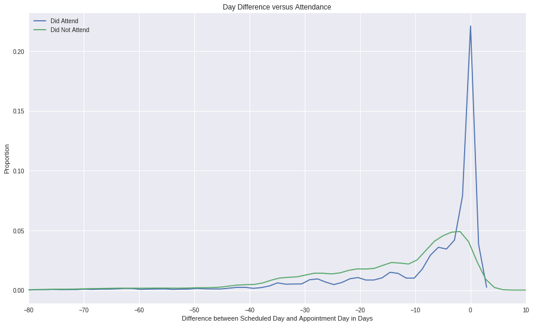

```python
# Create a larger figure and add a subplot.
fig = plt.figure(figsize=(15,9))
ax = fig.add_subplot(111)

# Create a column with the day difference between the 'ScheduledDay' and 'AppointmentDay' value in each record
#  (the days attribute of the dt attribute of the difference).
df['DayDifference'] = (df['ScheduledDay'] - df['AppointmentDay']).dt.days
sns.distplot(df[df['No-show'] == 'No'].DayDifference, hist=False, kde=True, label='Did Attend')
sns.distplot(df[df['No-show'] == 'Yes'].DayDifference, hist=False, kde=True, label='Did Not Attend')

# Set the x-axis limits so we aren't distracted by unhelpful information.
ax.set_xlim([-80, 10])

# Set appropriate labels.
plt.xlabel('Difference between Scheduled Day and Appointment Day in Days')
plt.ylabel('Proportion')
plt.title("Day Difference versus Attendance")

# The visualization is shown using plt.show() so as to avoid outputting distracting text.
plt.show()
```

In the above plot, we see that attended appointments vastly more often have a small difference between the scheduled day and appointment day. Appointments that are not attended tend to have a larger difference between the scheduled day and appointment day.

## Conclusions

Based on patient gender and age, as well as the prevalence of appointment non-attendance, the data does not seem representative, neither of the Brazilian population nor of the totality of medical appointments in Brazil. Of course, such a conclusion is not definite, as it may well be the case that vastly fewer males visit hospitals and about 20% of all appointments are not attended. The ages of patients in the sample seem a bit odd, though.

Next, we investigated univariate relationships between the given information and appointment attendance. The following variables were shown to have somewhat of a relationship with attendance and thus may have some predictive power:

- Age
- Scholarship
- Hypertension (hipertension)
- Diabetes
- Handicap (handcap)
- SMS received

A relationship between attendance and the following variables was not found:

- Gender
- Scheduled month
- Scheduled hour
- Appointment day
- Neighborhood
- Alcoholism

Curiously, the receiving of SMS seemed to correlate negatively with appointment attendance. If the messages are reminders then they are counterproductive. Further, with regard to all of the discovered relationships, neither directionality of the relationships nor whether the relationships were causal could be determined.